# The Boston House Price Dataset

Classic Machine Learning Approaches

Rick Scavetta

# Boston regression Example:

For this example, I’m going to use the exact same data that we’ll see later in deep learning so we can directly compare the results.

```r
# Read the dataset
boston <- read.csv("../data/boston_keras.csv")
```

We have 14 variables. The first 13 are the predictor variables and that last, `MEDV` is the response

| Variable | Description |
| --- | --- |
| `CRIM` | per capita crime rate by town |
| `ZN` | proportion of residential land zoned for lots over 25,000 sq.ft |
| `INDUS` | proportion of non-retail business acres per town |
| `CHAS` | Charles River dummy variable (1 if tract bounds river; else 0) |
| `NOX` | nitric oxides concentration (parts per 10 million) |
| `RM` | average number of rooms per dwelling |
| `AGE` | proportion of owner-occupied units built prior to 1940 |
| `DIS` | weighted distances to five Boston employment centres |
| `RAD` | index of accessibility to radial highways |
| `TAX` | full-value property-tax rate per $10,000 |
| `PTRATIO` | pupil-teacher ratio by town |
| `B` | 1000(Bk - 0.63)^2 where Bk is the proportion of blacks by town |
| `LSTAT` | % lower status of the population |
| `MEDV` | Median value of owner-occupied homes in $1000’s |

```r
summary(boston)
```

```
##       CRIM                ZN             INDUS            CHAS
##  Min.   : 0.00632   Min.   :  0.00   Min.   : 0.46   Min.   :0.00000
##  1st Qu.: 0.08204   1st Qu.:  0.00   1st Qu.: 5.19   1st Qu.:0.00000
##  Median : 0.25651   Median :  0.00   Median : 9.69   Median :0.00000
##  Mean   : 3.61352   Mean   : 11.36   Mean   :11.14   Mean   :0.06917
##  3rd Qu.: 3.67708   3rd Qu.: 12.50   3rd Qu.:18.10   3rd Qu.:0.00000
##  Max.   :88.97620   Max.   :100.00   Max.   :27.74   Max.   :1.00000
##       NOX               RM             AGE              DIS
##  Min.   :0.3850   Min.   :3.561   Min.   :  2.90   Min.   : 1.130
##  1st Qu.:0.4490   1st Qu.:5.886   1st Qu.: 45.02   1st Qu.: 2.100
##  Median :0.5380   Median :6.208   Median : 77.50   Median : 3.207
##  Mean   :0.5547   Mean   :6.285   Mean   : 68.57   Mean   : 3.795
##  3rd Qu.:0.6240   3rd Qu.:6.623   3rd Qu.: 94.08   3rd Qu.: 5.188
##  Max.   :0.8710   Max.   :8.780   Max.   :100.00   Max.   :12.127
##       RAD              TAX           PTRATIO            B
##  Min.   : 1.000   Min.   :187.0   Min.   :12.60   Min.   :  0.32
##  1st Qu.: 4.000   1st Qu.:279.0   1st Qu.:17.40   1st Qu.:375.38
##  Median : 5.000   Median :330.0   Median :19.05   Median :391.44
##  Mean   : 9.549   Mean   :408.2   Mean   :18.46   Mean   :356.67
##  3rd Qu.:24.000   3rd Qu.:666.0   3rd Qu.:20.20   3rd Qu.:396.23
##  Max.   :24.000   Max.   :711.0   Max.   :22.00   Max.   :396.90
##      LSTAT            MEDV
##  Min.   : 1.73   Min.   : 5.00
##  1st Qu.: 6.95   1st Qu.:17.02
##  Median :11.36   Median :21.20
##  Mean   :12.65   Mean   :22.53
##  3rd Qu.:16.95   3rd Qu.:25.00
##  Max.   :37.97   Max.   :50.00
```

## Check features:

Correlation of each independent variable with the dependent variable

```r
cor(boston,boston$MEDV) %>%
  data.frame() %>%
  knitr::kable() %>%
  kable_styling(full_width = F, position = "left")
```

|  | . |
| --- | --- |
| CRIM | -0.3883046 |
| ZN | 0.3604453 |
| INDUS | -0.4837252 |
| CHAS | 0.1752602 |
| NOX | -0.4273208 |
| RM | 0.6953599 |
| AGE | -0.3769546 |
| DIS | 0.2499287 |
| RAD | -0.3816262 |
| TAX | -0.4685359 |
| PTRATIO | -0.5077867 |
| B | 0.3334608 |
| LSTAT | -0.7376627 |
| MEDV | 1.0000000 |

Calulate near zero variance

```r
nzv <- nearZeroVar(boston, saveMetrics = TRUE)
```

There are 0 zero variance of near-zero variance variables.

# Create test set

```r
# as per the keras data set:
index <- 1:404

training <- boston[index,]
testing <- boston[-index,]
```

## Scaling:

We’ll perform z-score transformation on each predictor variable, after splitting, as we will do later in deep learning.

```r
# Using dplyr to keep data frame structure:
training %>%
  mutate_at(vars(-MEDV), scale) -> training

summary(training)
```

```
##        CRIM.V1              ZN.V1              INDUS.V1
##  Min.   :-0.404599   Min.   :-0.483017   Min.   :-1.5627588
##  1st Qu.:-0.396470   1st Qu.:-0.483017   1st Qu.:-0.8771342
##  Median :-0.376186   Median :-0.483017   Median :-0.2076592
##  Mean   : 0.000000   Mean   : 0.000000   Mean   : 0.0000000
##  3rd Qu.:-0.007608   3rd Qu.: 0.042907   3rd Qu.: 1.0270523
##  Max.   : 9.223411   Max.   : 3.724372   Max.   : 2.4423459
##        CHAS.V1              NOX.V1               RM.V1
##  Min.   :-0.256515   Min.   :-1.4694465   Min.   :-3.812523
##  1st Qu.:-0.256515   1st Qu.:-0.8897023   1st Qu.:-0.552745
##  Median :-0.256515   Median :-0.1650220   Median :-0.096623
##  Mean   : 0.000000   Mean   : 0.0000000   Mean   : 0.000000
##  3rd Qu.:-0.256515   3rd Qu.: 0.6278635   3rd Qu.: 0.481719
##  Max.   : 3.888763   Max.   : 2.6740197   Max.   : 3.462893
##         AGE.V1              DIS.V1               RAD.V1
##  Min.   :-2.3661085   Min.   :-1.285909   Min.   :-0.9703661
##  1st Qu.:-0.8423437   1st Qu.:-0.819209   1st Qu.:-0.6254735
##  Median : 0.3396253   Median :-0.294536   Median :-0.5105093
##  Mean   : 0.0000000   Mean   : 0.000000   Mean   : 0.0000000
##  3rd Qu.: 0.8979513   3rd Qu.: 0.678613   3rd Qu.: 1.6738104
##  Max.   : 1.1091131   Max.   : 3.433149   Max.   : 1.6738104
##         TAX.V1             PTRATIO.V1             B.V1
##  Min.   :-1.3096866   Min.   :-2.6704411   Min.   :-3.766431
##  1st Qu.:-0.7627280   1st Qu.:-0.5685332   1st Qu.: 0.211339
##  Median :-0.4561907   Median : 0.2835916   Median : 0.387487
##  Mean   : 0.0000000   Mean   : 0.0000000   Mean   : 0.000000
##  3rd Qu.: 1.5633491   3rd Qu.: 0.7835049   3rd Qu.: 0.439633
##  Max.   : 1.8338231   Max.   : 1.6015447   Max.   : 0.447522
##       LSTAT.V1            MEDV
##  Min.   :-1.517782   Min.   : 5.00
##  1st Qu.:-0.806504   1st Qu.:16.68
##  Median :-0.185514   Median :20.75
##  Mean   : 0.000000   Mean   :22.40
##  3rd Qu.: 0.599856   3rd Qu.:24.80
##  Max.   : 3.477707   Max.   :50.00
```

```r
# Using dplyr to keep data frame structure:
testing %>%
  mutate_at(vars(-MEDV), scale) -> testing

summary(testing)
```

```
##        CRIM.V1              ZN.V1              INDUS.V1
##  Min.   :-0.573083   Min.   :-0.505354   Min.   :-1.4179408
##  1st Qu.:-0.559733   1st Qu.:-0.505354   1st Qu.:-0.8201272
##  Median :-0.532900   Median :-0.505354   Median :-0.2074917
##  Mean   : 0.000000   Mean   : 0.000000   Mean   : 0.0000000
##  3rd Qu.: 0.127880   3rd Qu.: 0.247905   3rd Qu.: 0.9648441
##  Max.   : 4.085875   Max.   : 3.666541   Max.   : 2.3256288
##        CHAS.V1               NOX.V1               RM.V1
##  Min.   :-0.3280701   Min.   :-1.3830518   Min.   :-2.192592
##  1st Qu.:-0.3280701   1st Qu.:-0.8967527   1st Qu.:-0.577326
##  Median :-0.3280701   Median :-0.1104934   Median :-0.186152
##  Mean   : 0.0000000   Mean   : 0.0000000   Mean   : 0.000000
##  3rd Qu.:-0.3280701   3rd Qu.: 0.5894138   3rd Qu.: 0.415854
##  Max.   : 3.0182452   Max.   : 2.9709159   Max.   : 3.608085
##         AGE.V1              DIS.V1               RAD.V1
##  Min.   :-2.0957132   Min.   :-1.069963   Min.   :-1.0237424
##  1st Qu.:-0.8403315   1st Qu.:-0.796063   1st Qu.:-0.6817498
##  Median : 0.2376780   Median :-0.288714   Median :-0.5677523
##  Mean   : 0.0000000   Mean   : 0.000000   Mean   : 0.0000000
##  3rd Qu.: 0.8998101   3rd Qu.: 0.531379   3rd Qu.: 1.5982005
##  Max.   : 1.1417595   Max.   : 3.409500   Max.   : 1.5982005
##         TAX.V1             PTRATIO.V1             B.V1
##  Min.   :-1.2993933   Min.   :-2.6517411   Min.   :-4.290125
##  1st Qu.:-0.7793541   1st Qu.:-0.4808155   1st Qu.: 0.170956
##  Median :-0.4932621   Median : 0.2592727   Median : 0.353137
##  Mean   : 0.0000000   Mean   : 0.0000000   Mean   : 0.000000
##  3rd Qu.: 1.4008644   3rd Qu.: 0.9006826   3rd Qu.: 0.412148
##  Max.   : 1.6545420   Max.   : 1.3940747   Max.   : 0.413664
##        LSTAT.V1            MEDV
##  Min.   :-1.5511381   Min.   : 5.60
##  1st Qu.:-0.7468546   1st Qu.:18.65
##  Median :-0.1860218   Median :21.95
##  Mean   : 0.0000000   Mean   :23.08
##  3rd Qu.: 0.5391029   3rd Qu.:27.07
##  Max.   : 2.9400050   Max.   :50.00
```

# GLM using all features

Our linear model will take the form:

$$Y_i = \beta_0 + \beta_1 X_{i1} + \beta_2 X_{i2} + \ldots + \beta_p X_{ip} + \epsilon_i$$
. The coefficients are:

```r
fit_lm <- lm(MEDV~.,data = training)

data.frame(coef = round(fit_lm$coefficients,2)) %>%
  knitr::kable()
```

|  | coef |
| --- | --- |
| (Intercept) | 22.40 |
| CRIM | -1.11 |
| ZN | 1.35 |
| INDUS | 0.03 |
| CHAS | 1.00 |
| NOX | -2.40 |
| RM | 2.40 |
| AGE | 0.21 |
| DIS | -3.48 |
| RAD | 2.91 |
| TAX | -1.96 |
| PTRATIO | -1.99 |
| B | 0.82 |
| LSTAT | -4.03 |

```r
#predict on test set
pred_lm <- predict(fit_lm, newdata = testing)

MAE_lm <- sum(abs(pred_lm - testing$MEDV))/102
```

Our measure for the error will be the mean absolute error (MAE):

$$\mathrm{MAE} = \frac{\sum_{i=1}^n\left| y_i-\hat{y_i}\right|}{n} = \frac{\sum_{i=1}^n\left| e_i\right|}{n}$$

$$\operatorname{MSE} = \frac{\sum_{i=1}^n(y_i-\hat{y_i})^2}{n} = \frac{\sum_{i=1}^n{e_i^2}}{n}$$

$$\operatorname{RMSE} = \sqrt{MSE}$$

the MSE will also make a reappearance in deep learning as our loss function.

The MAE using the linear model is 3.3162743. In dollar amounts, we are off by 3316, much better than before.

## Random Forest

Let’s give it another go using a differen method.

```r
fit_rf <- randomForest(MEDV ~ ., data = training)

pred_rf <- predict(fit_rf, testing)

MAE_rf <- sum(abs(pred_rf - testing$MEDV))/102
```

In this case the MAE is 2.5439377. In dollar amounts, we are off by 2544, much better than before.

## Visualizing output

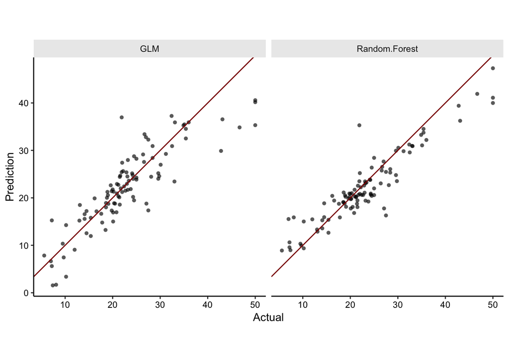

The results are saved in the `ClassicML.csv` file so that we can comper them with the results from deep learning.